# TWFE Regressions

## Synthetic Control Method - Creation of Synthetic Neuchatel

Optimal predictor is solely unemployment rate.

```r
# According to results above, only use Arbeitslosenquote
dataprep.out <- dataprep(data_scm_control_df,
    predictors             = c("Arbeitslosenquote"),  # Kontrollvariablen
    dependent              = "Arbeitslosenquote",             # Y-Variable (abhängige Variable)
    unit.variable          = "StateID",                        # Kanton als Einheit
    time.variable          = "Year2",                          # Jahr als Zeitvariable
    unit.names.variable    = "Kanton",                        # Name der Kantone
    treatment.identifier   = 13,                               # Neuenburg als Treatment
    controls.identifier    = setdiff(unique(data_scm_control_df$StateID), 13), # Alle Kanton
    time.predictors.prior  = 1:108,                       # Zeitraum vor dem Treatment zur Erstellung der synthetischen Kontrolle
    time.optimize.ssr      = 1:108,                       # Zeitraum zur Optimierung
    time.plot              = 1:204                        # Zeitraum für die Analyse
)

# weigth table
synth.out <- synth(dataprep.out)
```

```
##
## X1, X0, Z1, Z0 all come directly from dataprep object.
##
##
## ****************
##  optimization over w weights: computing synthtic control unit
##
##
##
## ****************
## ****************
## ****************
##
## MSPE (LOSS V): 0.0001184823
##
## solution.v:
##  1
##
## solution.w:
##  0.0446655 0.04027431 0.0443417 0.04560208 0.04170433 0.04563182 0.04238703 0.04255236 0.04571236 0.04367678 0.04566403 0.04420324 0.0456552 0.04390094 0.04328808 0.2512065 0.04438463 0.04514917
```

```r
synth.tables <- synth.tab(
    dataprep.res = dataprep.out,
    synth.res    = synth.out)

print(synth.tables)
```

```
## $tab.pred
##                   Treated Synthetic Sample Mean
## Arbeitslosenquote   0.072     0.072       0.065
##
## $tab.v
##                   v.weights
## Arbeitslosenquote         1
##
## $tab.w
##    w.weights            unit.names unit.numbers
## 26     0.045                Zürich           26
## 6      0.040                  Bern            6
## 12     0.044                Luzern           12
## 22     0.046                   Uri           22
## 17     0.042                Schwyz           17
## 15     0.046              Obwalden           15
## 14     0.042             Nidwalden           14
## 9      0.043                Glarus            9
## 25     0.046                   Zug           25
## 18     0.044             Solothurn           18
## 4      0.046      Basel-Landschaft            4
## 16     0.044          Schaffhausen           16
## 3      0.046 Appenzell Innerrhoden            3
## 19     0.044            St. Gallen           19
## 1      0.043                Aargau            1
## 21     0.251               Thurgau           21
## 20     0.044                Tessin           20
## 24     0.045                Wallis           24
##
## $tab.loss
##            Loss W       Loss V
## [1,] 5.883484e-10 0.0001184823
```

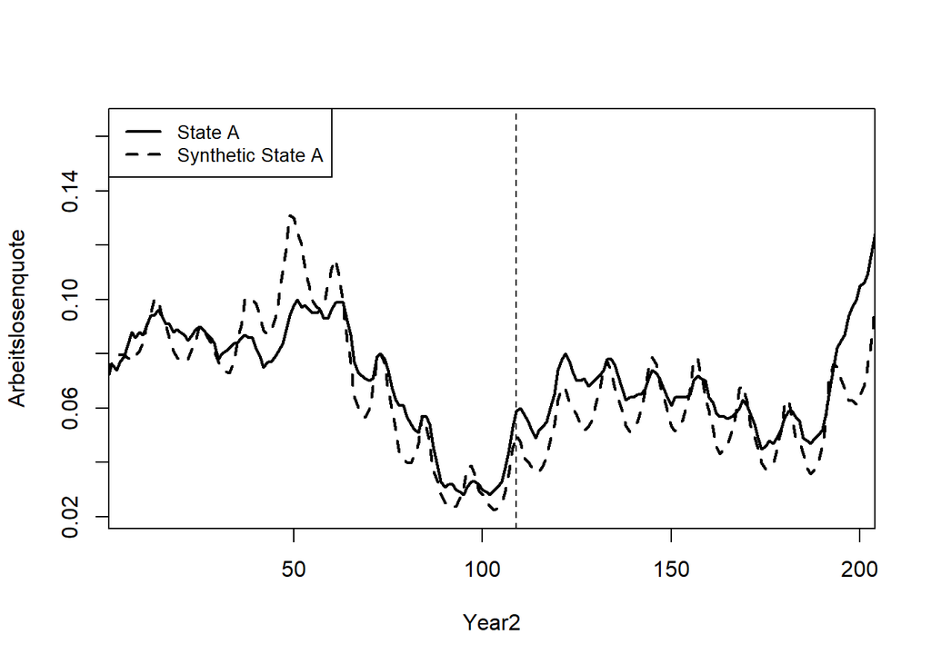

```r
## synth plot
path.plot(synth.res    = synth.out,
          dataprep.res = dataprep.out,
          Ylab         = c("Arbeitslosenquote"),
          Xlab         = c("Year2"),
          Legend       = c("State A","Synthetic State A"),
          Legend.position = c("topleft")
)
abline(v   = 109,
       lty = 2)
```

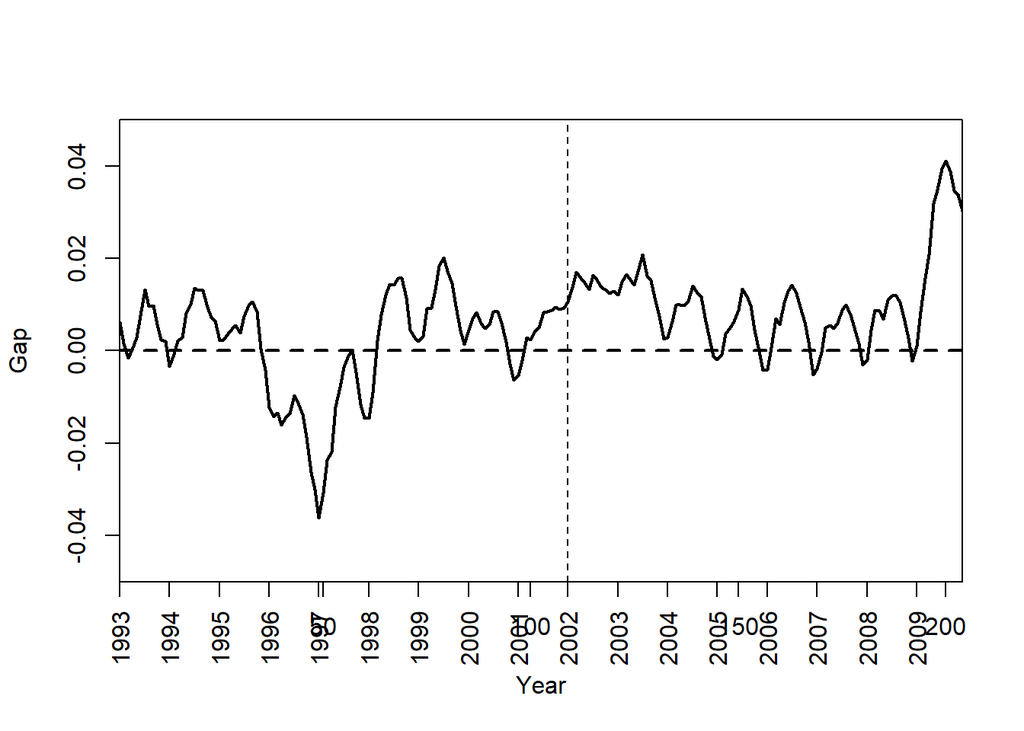

```r
# GAP plot
# First, create your gaps.plot normally
gaps.plot(synth.res    = synth.out3,
          dataprep.res = dataprep.out3,
          Ylab         = c("Gap"),
          Xlab         = c("Year"),
          Ylim         = c(-0.05, 0.05),
          Main         = ""
)
abline(v = 109, lty = 2)

# Add custom x-axis labels
axis(1, at = seq(1, 204, by = 12), labels = seq(1993, 2009, by = 1), las = 2)
```

```r
## create new Dataset
# Extract u for synthetic Neuenburg
synth_neuenburg <- as.numeric(dataprep.out$Y0plot %*% synth.out$solution.w)



# Create new dataframe for Synthetic Neuenburg
synthetic_neuenburg_df <- data_scm_control_df %>%
  filter(StateID == 13) %>%                # Filter to get the structure of Neuenburg
  mutate(StateID = 27,                     # Assign a new StateID for synthetic Neuenburg
         Kanton = "Synthetic Neuenburg",   # Name it "Synthetic Neuenburg"
         Arbeitslosenquote = synth_neuenburg)

# Combine datasets
data_scm_all <- bind_rows(data_scm_control_df, synthetic_neuenburg_df)
```

### GAP Plot - for all SCM

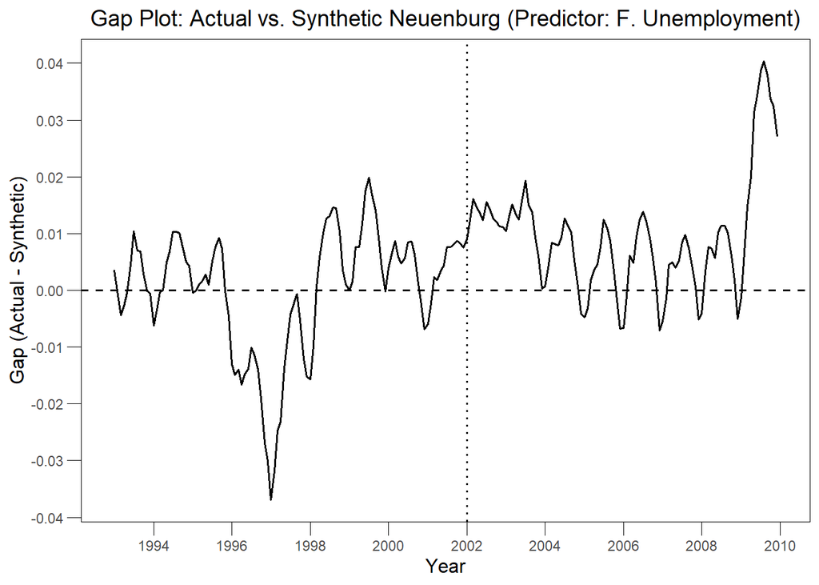

```r
### GAP for Predictor: Foreigner Unemployment Rate
# Calculate the gap between actual and synthetic Neuenburg
gap_data <- data_scm_control_df %>%
  filter(StateID == 13) %>%  # Filter actual Neuenburg data
  mutate(Gap = Arbeitslosenquote - synth_neuenburg)
gap_data$Datum <- as.Date(gap_data$Datum)

# Create a data frame for plotting
gap_plot_data <- data.frame(
  Year = gap_data$Datum,
  Gap = gap_data$Gap
)

# create GAP plot for Predictor: F. Unemployment
ggplot() +
  # Plot the gap line using the provided data
  geom_line(data = gap_plot_data, aes(x = Year, y = Gap), size = 0.6, color = "black") +
  # Add a vertical dotted line at the policy implementation year (2002)
  geom_vline(xintercept = as.Date("2002-01-01"), linetype = "dotted", color = "black", size = 0.6) +
  # Add a horizontal dashed line at y = 0
  geom_hline(yintercept = 0, linetype = "dashed", color = "black", size = 0.6) +
  # Customize x-axis labels for date format
  scale_x_date(date_breaks = "2 years", date_labels = "%Y") +
  scale_y_continuous(breaks = seq(-0.05, 0.05, by = 0.01)) +
  # Labels and title
  labs(
    title = "Gap Plot: Actual vs. Synthetic Neuenburg (Predictor: F. Unemployment)",
    x = "Year",
    y = "Gap (Actual - Synthetic)"
  ) +
  # Apply formatting
  theme_minimal() +
  theme(
    legend.title = element_blank(),
    legend.position = "none",  # No legend needed since it's a single line
    panel.border = element_rect(color = "black", fill = NA, size = 0.3),
    panel.grid = element_blank(),
    axis.ticks = element_line(color = "black", size = 0.3),
    axis.ticks.length = unit(0.3, "cm"),
    axis.title.x = element_text(size = 12),
    axis.title.y = element_text(size = 12),
    plot.title = element_text(hjust = 0.5, size = 14)
  )
```

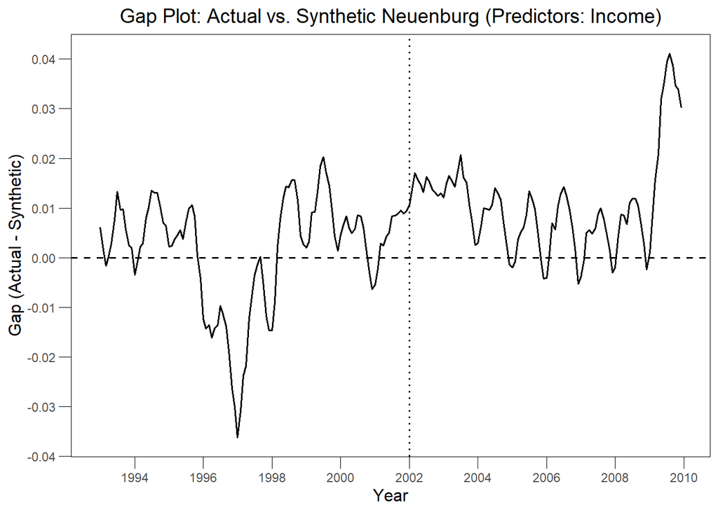

```r
### GAP for Predictor: Income
# Calculate the gap between actual and synthetic Neuenburg in this case
# Calculate the gap between actual and synthetic Neuchâtel
gap_data1 <- data_scm_control_df %>%
  filter(StateID == 13) %>%  # Filter for actual Neuchâtel data
  mutate(Gap = Arbeitslosenquote - as.numeric(dataprep.out3$Y0plot %*% synth.out3$solution.w))
gap_data1$Datum <- as.Date(gap_data1$Datum)

# Create a data frame for plotting
gap_plot_data1 <- data.frame(
  Year = gap_data1$Datum,
  Gap = gap_data1$Gap
)

# # create GAP plot for Predictor: Income
ggplot() +
  geom_line(data = gap_plot_data1, aes(x = Year, y = Gap), size = 0.6, color = "black") +
  geom_vline(xintercept = as.Date("2002-01-01"), linetype = "dotted", color = "black", size = 0.6) +
  geom_hline(yintercept = 0, linetype = "dashed", color = "black", size = 0.6) +
  scale_x_date(date_breaks = "2 years", date_labels = "%Y") +
  scale_y_continuous(breaks = seq(-0.05, 0.05, by = 0.01)) +
  labs(
    title = "Gap Plot: Actual vs. Synthetic Neuenburg (Predictors: Income)",
    x = "Year",
    y = "Gap (Actual - Synthetic)"
  ) +
  theme_minimal() +
  theme(
    legend.title = element_blank(),
    legend.position = "none",
    panel.border = element_rect(color = "black", fill = NA, size = 0.3),
    panel.grid = element_blank(),
    axis.ticks = element_line(color = "black", size = 0.3),
    axis.ticks.length = unit(0.3, "cm"),
    axis.title.x = element_text(size = 12),
    axis.title.y = element_text(size = 12),
    plot.title = element_text(hjust = 0.5, size = 14)
  )
```

## Plot for Parallel Trend Assumption

I created a similar plot as before in the regular TWFE Model to include in the paper.

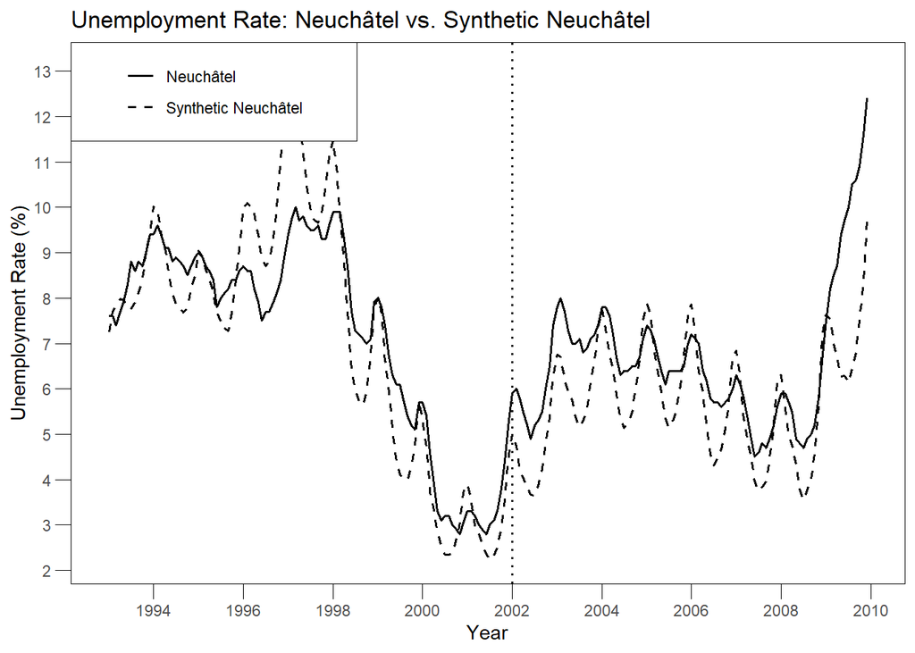

```r
## filter dataset for only Neuchatel and Synthetic
plot_data_scm <- data_scm_all %>%
  mutate(Arbeitslosenquote = Arbeitslosenquote * 100) %>%
  filter(Kanton %in% c("Neuenburg", "Synthetic Neuenburg"))

## Create plot for Neuchatel and Synthetic Neuchatel
ggplot() +
  geom_line(data = plot_data_scm %>% filter(Kanton == "Synthetic Neuenburg"), aes(x = Datum, y = Arbeitslosenquote, linetype = "Synthetic Neuchâtel"), size = 0.6, color = "black") +
  geom_vline(xintercept = as.Date("2002-01-01"), linetype = "dotted", color = "black", size = 0.6) +
  geom_line(data = plot_data_scm %>% filter(Kanton == "Neuenburg"),
            aes(x = Datum, y = Arbeitslosenquote, linetype = "Neuchâtel"),
            size = 0.6, color = "black") +
  scale_linetype_manual(values = c("Neuchâtel" = "solid", "Synthetic Neuchâtel" = "dashed")) +
  scale_x_date(date_breaks = "2 years", date_labels = "%Y") +
  scale_y_continuous(breaks = seq(0, 15, by = 1)) +
  labs(title = "Unemployment Rate: Neuchâtel vs. Synthetic Neuchâtel",
       x = "Year",
       y = "Unemployment Rate (%)") +
  theme_minimal() +
  theme(
    legend.title = element_blank(),
    legend.position = c(0, 1),
    legend.justification = c("left", "top"),
    legend.background = element_rect(color = "black", fill = "white", size = 0.2),
    legend.margin = margin(10, 30, 10, 30),
    panel.border = element_rect(color = "black", fill = NA, size = 0.3),
    panel.grid = element_blank(),
    axis.ticks = element_line(color = "black", size = 0.3),
    axis.ticks.length = unit(0.3, "cm")
  )
```

## Synthetic Control Method - TWFE Regression for DiD Analysis

Again use TWFE to analyse policy impact. I created multiple time periods to observe dynamic treatment effects.

```r
# correct treatment and post variable
data_scm_all_twfe <- data_scm_all %>%
  mutate(
    treatment = ifelse(Kanton == "Neuenburg", 1, 0),
    post = ifelse(Jahr >= 2002, 1, 0))

# regressions with time variation
model_scm_total <- fixest::feols(Arbeitslosenquote ~ i(post, treatment) | time_numeric,
                         data = data_scm_all_twfe %>% filter(
                           Kanton %in% c("Neuenburg", "Synthetic Neuenburg")),
                              vcov = "HC1")
model_scm_1998 <- fixest::feols(Arbeitslosenquote ~ i(post, treatment) | time_numeric,
                              data = data_scm_all_twfe %>%
                                filter(Kanton %in% c("Neuenburg", "Synthetic Neuenburg"),
                                       Jahr >= 1998),
                              vcov = "HC1")

model_scm_2005 <- fixest::feols(Arbeitslosenquote ~ i(post, treatment) | time_numeric,
                              data = data_scm_all_twfe %>%
                                filter(Kanton %in% c("Neuenburg", "Synthetic Neuenburg"),
                                       Jahr >= 1998, Jahr <= 2005),
                              vcov = "HC1")
model_scm_2005_2007 <- fixest::feols(Arbeitslosenquote ~ i(post, treatment) | time_numeric,
                              data = data_scm_all_twfe %>%
                                filter(Kanton %in% c("Neuenburg", "Synthetic Neuenburg"),
                                       Jahr >= 1998, Jahr < 2002 | Jahr > 2005, Jahr <= 2007),
                              vcov = "HC1")
model_scm_2007_2009 <- fixest::feols(Arbeitslosenquote ~ i(post, treatment) | time_numeric,
                              data = data_scm_all_twfe %>%
                                filter(Kanton %in% c("Neuenburg", "Synthetic Neuenburg"),
                                       Jahr >= 1998, Jahr < 2002 | Jahr > 2007, Jahr <= 2009),
                              vcov = "HC1")

# table
etable(model_scm_total, model_scm_1998, model_scm_2005, model_scm_2005_2007, model_scm_2007_2009)
```

```
##                         model_scm_total     model_scm_1998     model_scm_2005
## Dependent Var.:       Arbeitslosenquote  Arbeitslosenquote  Arbeitslosenquote
##
## treatment x post = 0   4.48e-7 (0.0011) 0.0057*** (0.0010) 0.0057*** (0.0010)
## treatment x post = 1 0.0093*** (0.0010) 0.0093*** (0.0010) 0.0086*** (0.0009)
## Fixed-Effects:       ------------------ ------------------ ------------------
## time_numeric                        Yes                Yes                Yes
## ____________________ __________________ __________________ __________________
## S.E. type            Heteroskedas.-rob. Heteroskedas.-rob. Heteroskedas.-rob.
## Observations                        408                288                192
## R2                              0.94353            0.94185            0.96911
## Within R2                       0.27171            0.45828            0.55360
##
##                      model_scm_20..2007 model_scm_20..2009
## Dependent Var.:       Arbeitslosenquote  Arbeitslosenquote
##
## treatment x post = 0 0.0057*** (0.0010) 0.0057*** (0.0010)
## treatment x post = 1  0.0041** (0.0012) 0.0159*** (0.0030)
## Fixed-Effects:       ------------------ ------------------
## time_numeric                        Yes                Yes
## ____________________ __________________ __________________
## S.E. type            Heteroskedas.-rob. Heteroskedas.-rob.
## Observations                        144                144
## R2                              0.97170            0.95634
## Within R2                       0.38557            0.51437
## ---
## Signif. codes: 0 '***' 0.001 '**' 0.01 '*' 0.05 '.' 0.1 ' ' 1
```

## Synthetic Control Method - Placebo Test

I conduct a Placebo Test in which I assign each control canton as treatment canton once and calculate Post and ére RMSPE and calculate the share of it.

```r
### Neuenburg
## again calculate Synthetic Neuchatel
dataprep.out_NE <- dataprep(data_scm_control_df,
    predictors             = c("Arbeitslosenquote"),
    dependent              = "Arbeitslosenquote",
    unit.variable          = "StateID",
    time.variable          = "Year2",
    unit.names.variable    = "Kanton",
    treatment.identifier   = 13,
    controls.identifier    = setdiff(unique(data_scm_control_df$StateID), 13),
    time.predictors.prior  = 1:108,
    time.optimize.ssr      = 1:108,
    time.plot              = 1:204)

# weight table
synth.out_NE <- synth(dataprep.out)
```

```
##
## X1, X0, Z1, Z0 all come directly from dataprep object.
##
##
## ****************
##  optimization over w weights: computing synthtic control unit
##
##
##
## ****************
## ****************
## ****************
##
## MSPE (LOSS V): 0.0001184823
##
## solution.v:
##  1
##
## solution.w:
##  0.0446655 0.04027431 0.0443417 0.04560208 0.04170433 0.04563182 0.04238703 0.04255236 0.04571236 0.04367678 0.04566403 0.04420324 0.0456552 0.04390094 0.04328808 0.2512065 0.04438463 0.04514917
```

```r
## extract data for synt. Neuchatel
neuenburg_actual <- dataprep.out_NE$Y1plot

neuenburg_synthetic <- dataprep.out_NE$Y0plot %*% synth.out_NE$solution.w

# calculate overall gaps between Neucahtel and Synt. Neuchatel
gap_values <- neuenburg_actual - neuenburg_synthetic

# define Pre- and Post-treatment period
pre_treatment_period <- 1:108
post_treatment_period <- 109:204

# calculate pre RMSPE
pre_rmspe <- sqrt(mean(gap_values[pre_treatment_period]^2))

# Calculate post RMSPE
post_rmspe <- sqrt(mean(gap_values[post_treatment_period]^2))

# calculate Share of RMSPE
rmspe_ratio_neuenburg <- post_rmspe / pre_rmspe


### Permutation Placebo Test (individually check all control cantons)
# create empty data.frame for RMSPE ratio
placebo_results <- data.frame(Kanton = character(), RMSPE_Ratio = numeric(), stringsAsFactors = FALSE)

# Iteration for all cantons except Neuchatel
for (kanton_id in unique(data_scm_control_df$StateID)) {
  if (kanton_id == 13) next  # skip Neuchatel

  # dataprep for all placebo cantons
  dataprep.out_placebo <- dataprep(
    data_scm_control_df,
    predictors             = c("Arbeitslosenquote"),
    dependent              = "Arbeitslosenquote",
    unit.variable          = "StateID",
    time.variable          = "Year2",
    unit.names.variable    = "Kanton",
    treatment.identifier   = kanton_id,
    controls.identifier    = setdiff(unique(data_scm_control_df$StateID), kanton_id),
    time.predictors.prior  = 1:108,
    time.optimize.ssr      = 1:108,
    time.plot              = 1:204
  )

  # extraction of data
  synth.out_placebo <- synth(dataprep.out_placebo)
  synth_kanton <- as.numeric(dataprep.out_placebo$Y0plot %*% synth.out_placebo$solution.w)

  # calculate RMSPE values
  pre_treatment_period <- 1:108
  post_treatment_period <- 109:204
  pre_rmspe <- sqrt(mean((dataprep.out_placebo$Y1plot[pre_treatment_period] - synth_kanton[pre_treatment_period])^2))
  post_rmspe <- sqrt(mean((dataprep.out_placebo$Y1plot[post_treatment_period] - synth_kanton[post_treatment_period])^2))

  # Berechne das RMSPE-Verhältnis und speichere das Ergebnis
  rmspe_ratio <- post_rmspe / pre_rmspe
  placebo_results <- rbind(placebo_results, data.frame(Kanton = unique(data_scm_control_df$Kanton[data_scm_control_df$StateID == kanton_id]), RMSPE_Ratio = rmspe_ratio))
}
```

[output not shown]

[output cut: 322 more lines]

[output not shown]

```r
# add Neuchatel to Control Cantons
placebo_results <- rbind(placebo_results, data.frame(Kanton = "Neuenburg", RMSPE_Ratio = rmspe_ratio_neuenburg))

# show results
print(placebo_results)
```

```
##                   Kanton RMSPE_Ratio
## 1                 Zürich   0.9693367
## 2                   Bern   1.5427967
## 3                 Luzern   1.1038003
## 4                    Uri   1.2353058
## 5                 Schwyz   1.1050343
## 6               Obwalden   0.6344710
## 7              Nidwalden   0.6963304
## 8                 Glarus   0.5020294
## 9                    Zug   1.2968478
## 10             Solothurn   0.8758204
## 11      Basel-Landschaft   0.5648644
## 12          Schaffhausen   1.2007052
## 13 Appenzell Innerrhoden   0.5865493
## 14            St. Gallen   1.2404023
## 15                Aargau   0.7724099
## 16               Thurgau   0.4826382
## 17                Tessin   0.8718290
## 18                Wallis   0.9156664
## 19             Neuenburg   1.2437059
```

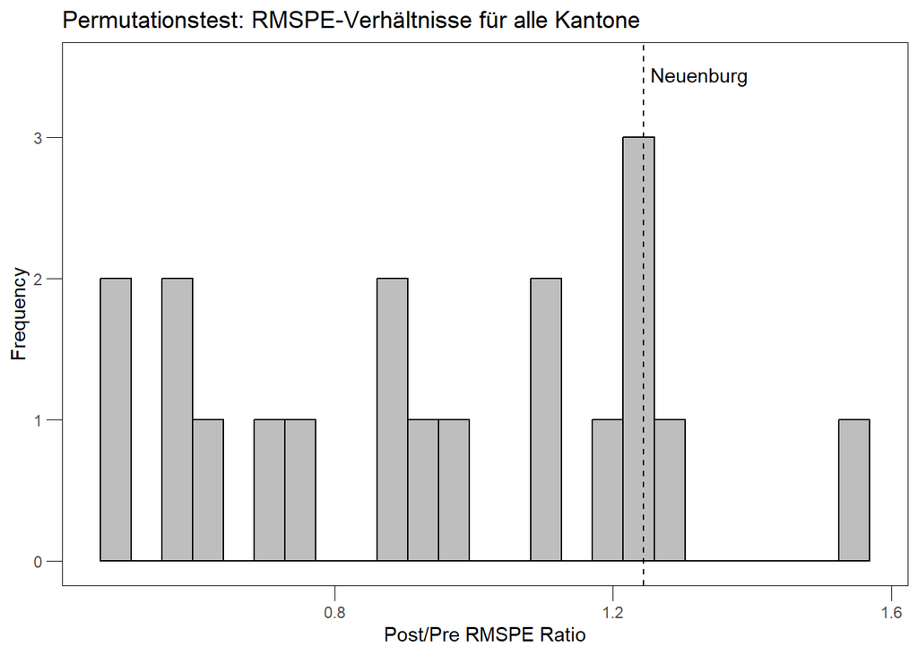

```r
# ggplot to visualize distribution
ggplot(placebo_results, aes(x = RMSPE_Ratio)) +
  geom_histogram(bins = 25, fill = "gray", color = "black") +
  geom_vline(aes(xintercept = rmspe_ratio_neuenburg), color = "black", linetype = "dashed", size = 0.5) +
  labs(title = "Permutationstest: RMSPE-Verhältnisse für alle Kantone",
       x = "Post/Pre RMSPE Ratio",
       y = "Frequency") +
  annotate("text", x = rmspe_ratio_neuenburg + 0.08, y = 3.5, label = "Neuenburg", color = "black", vjust = 1) +
  theme_minimal() +
    theme(
    panel.border = element_rect(color = "black", fill = NA, size = 0.3),
    panel.grid = element_blank(),
    axis.ticks = element_line(color = "black", size = 0.3),
    axis.ticks.length = unit(0.3, "cm")
  )
```

```r
ggsave("Permutatoin_test_SCM.png",        # Dateiname und Format (.png, .jpg, .pdf, etc.)
       plot = last_plot(),                  # Zu speichernder Plot, hier der zuletzt erstellte
       width = 10,                          # Breite in Zoll
       height = 5,                          # Höhe in Zoll
       dpi = 300,                           # Auflösung in DPI
       bg = "white")


## Calculation of Percentile-Rank for Neuchatel
neuenburg_percentile <- sum(placebo_results$RMSPE_Ratio <= rmspe_ratio_neuenburg) / nrow(placebo_results) * 100
cat("RSMPE Ratio for Neuchatel lies within", neuenburg_percentile, "Percnetile of all Cantons.\n")
```

```
## RSMPE Ratio for Neuchatel lies within 89.47368 Percnetile of all Cantons.
```

### Synthetic Control Method

```r
# First: calculate initial Synthetc Canton with all control cantons
dataprep.out_full <- dataprep(
  foo = data_scm_control_df,
  predictors = c("Arbeitslosenquote"),
  dependent = "Arbeitslosenquote",
  unit.variable = "StateID",
  time.variable = "Year2",
  treatment.identifier = 13,  # Neuchatel as Treatment
  controls.identifier = setdiff(unique(data_scm_control_df$StateID), 13),
  time.predictors.prior = 1:108,
  time.optimize.ssr = 1:108,
  time.plot = 1:204
)

synth.out_full <- synth(dataprep.out_full)
```

```
##
## X1, X0, Z1, Z0 all come directly from dataprep object.
##
##
## ****************
##  optimization over w weights: computing synthtic control unit
##
##
##
## ****************
## ****************
## ****************
##
## MSPE (LOSS V): 0.0001184823
##
## solution.v:
##  1
##
## solution.w:
##  0.0446655 0.04027431 0.0443417 0.04560208 0.04170433 0.04563182 0.04238703 0.04255236 0.04571236 0.04367678 0.04566403 0.04420324 0.0456552 0.04390094 0.04328808 0.2512065 0.04438463 0.04514917
```

```r
synth_main <- (dataprep.out_full$Y0plot %*% synth.out_full$solution.w) * 100

# Second: reduce numbers of Controls iteratively by 1
control_cantons <- setdiff(unique(data_scm_control_df$StateID), 13)
num_controls <- length(control_cantons)
synth_leave_one_out <- list()  # save results

for (k in num_controls:2) {
  # Wähle zufällig k Kontrollkantone aus
  selected_controls <- sample(control_cantons, k)

  # calculate Synthetic control with choosen cantons
  dataprep.out_iter <- dataprep(
    foo = data_scm_control_df,
    predictors = c("Arbeitslosenquote"),
    dependent = "Arbeitslosenquote",
    unit.variable = "StateID",
    time.variable = "Year2",
    treatment.identifier = 13,
    controls.identifier = selected_controls,
    time.predictors.prior = 1:108,
    time.optimize.ssr = 1:108,
    time.plot = 1:204
  )

  synth.out_iter <- synth(dataprep.out_iter)
  synth_leave_one_out[[k]] <- (dataprep.out_iter$Y0plot %*% synth.out_iter$solution.w) * 100
}
```

[output not shown]

[output cut: 301 more lines]

[output not shown]

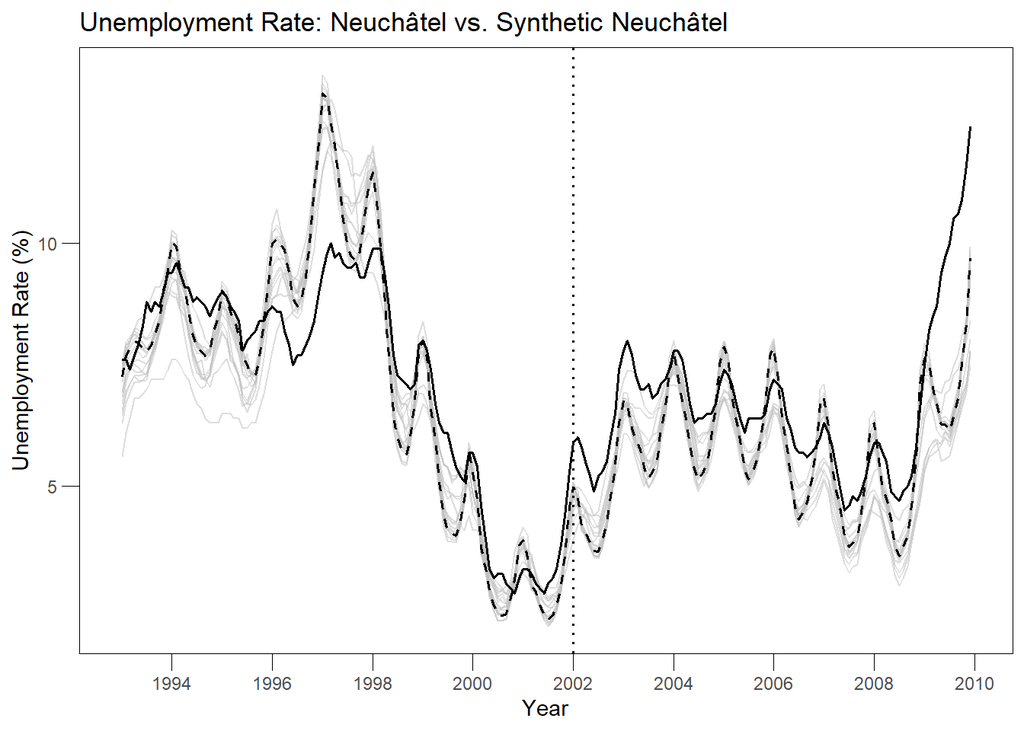

```r
# 3. add years to plot
plot_data <- data.frame(
  Year2 = 1:204,
  Datum = seq(as.Date("1993-01-01"), by = "month", length.out = 204),  # Monatliche Daten ab 1993-01-01
  Neuchatel = dataprep.out_full$Y1plot * 100,  # Tatsächliche Werte für Neuenburg, skaliert
  SyntheticMain = synth_main  # Hauptsynthetische Kontrolle mit allen Kontrollkantonen, skaliert
)

# add leave-one out results
for (k in num_controls:2) {
  plot_data[[paste0("SyntheticLeave", k)]] <- synth_leave_one_out[[k]]
}

# filter for data used in plot
plot_data_grey <- plot_data %>% filter(Datum >= as.Date("1993-01-01"))

# plot using ggplot
p <- ggplot(plot_data_grey, aes(x = Datum)) +
  lapply(2:num_controls, function(k) {
    leave_one_out_col <- paste0("SyntheticLeave", k)
    if (leave_one_out_col %in% names(plot_data_grey)) {
      geom_line(aes_string(y = leave_one_out_col), color = "grey", linetype = "solid", alpha = 0.5)
    }
  }) +
  labs(title = "Unemployment Rate: Neuchâtel vs. Synthetic Neuchâtel",
       x = "Year",
       y = "Unemployment Rate (%)") +
  scale_x_date(date_breaks = "2 years", date_labels = "%Y") +
  theme_minimal() +
  theme(
    legend.position = "none",
    panel.border = element_rect(color = "black", fill = NA, size = 0.3),
    panel.grid = element_blank(),
    axis.ticks = element_line(color = "black", size = 0.3),
    axis.ticks.length = unit(0.3, "cm")
  )

# add vertical lines
p <- p +
  geom_line(data = plot_data, aes(x = Datum, y = X13),
            color = "black", size = 0.6, linetype = "solid") +
  geom_line(data = plot_data, aes(x = Datum, y = w.weight),
            color = "black", size = 0.6, linetype = "dashed") +
  geom_vline(xintercept = as.Date("2002-01-01"), linetype = "dotted",
             color = "black", size = 0.6)

# show final diagram
print(p)
```